# Practical Machine Learning Project

# Introduction and data loading

The main issue of this project is to predict the way 6 participants perform exercice taking into account different variables obtainid with different devices placed in different parts of the participant’s body. In order to perform the prediction, different machine learning algorithms were used.

Before startint the analysis, different package should be loaded into R:

```r
library(caret)
```

```r
library(rpart)
library(rpart.plot)
library(randomForest)
library(rattle)
library(reshape)
library(pander)
```

After it, training and test samples are also loaded:

```r
trainUrl <-"https://d396qusza40orc.cloudfront.net/predmachlearn/pml-training.csv"
testUrl <- "https://d396qusza40orc.cloudfront.net/predmachlearn/pml-testing.csv"
trainFile <- "./data/pml-training.csv"
testFile  <- "./data/pml-testing.csv"
if (!file.exists("./data")) {
  dir.create("./data")
}
if (!file.exists(trainFile)) {
  download.file(trainUrl, destfile = trainFile, method = "curl")
}
if (!file.exists(testFile)) {
  download.file(testUrl, destfile = testFile, method = "curl")
}
trainRaw <- read.csv("./data/pml-training.csv")
testRaw <- read.csv("./data/pml-testing.csv")
```

# Data filtering

In order to obtain a clean data frame to work with, some uninformative variables were discarded:

## 1) Near Zero Variance Variables

```r
NZV <- nearZeroVar(trainRaw, saveMetrics = TRUE)

training01 <- trainRaw[, !NZV$nzv]
testing01 <- testRaw[, !NZV$nzv]
```

## 2) Columns that contain `NA's`

```r
cond <- (colSums(is.na(training01)) == 0)
training02 <- training01[, cond]
testing02 <- testing01[, cond]
```

## 3) Columns that do not contribute much to the measurements

```r
not_useful <- grepl("^X|timestamp|user_name", names(training02))
training03 <- training02[, !not_useful]
testing03 <- testing02[, !not_useful]
```

If the value distribution is evaluated regarding the `classe` variable:

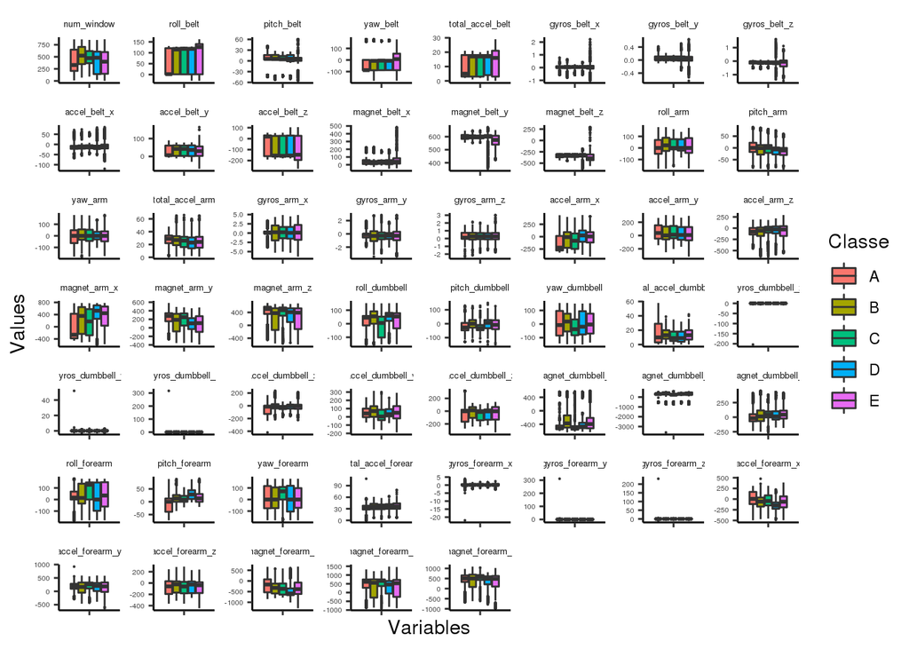

```r
df.m <- melt(training03, id.var = "classe")
p <- ggplot(data = df.m[1:1039966,]) +
  geom_boxplot(aes(x=variable[1:1039966], y=as.numeric(value[1:1039966]),
                   fill=classe[1:1039966]), outlier.size = 0.05)
p + theme_classic() + facet_wrap( ~ variable[1:1039966], scales="free") +
  xlab("Variables") + ylab("Values") +
  guides(fill=guide_legend(title="Classe"))+
  theme(axis.text.x = element_blank(),
        axis.text.y = element_text(size = 4),
        strip.text =element_text(size=5),
        strip.background = element_blank())
```

Some variables present clear differences looking at the `classe` variable. However, it is important to mention that are some values that are clearly overlayers. Although in this exercices the variable would not be removed, a possible solution for this, would be a normalization of the data or simply discard these data points.

# Machine learning analysis

Before starting the analysis, the training data is splitted gain to get a validation data to check the machine learning algorithm performance.

```r
set.seed(12345)
inTrain <- createDataPartition(training03$classe, p = 0.70, list = FALSE)
validation <- training03[-inTrain, ]
training <- training03[inTrain, ]
```

In the following steps, different machine learning algorithms are performed using always the same control method:

```r
fitControl <- trainControl(method = "cv", number = 5)
```

## 1) KNN

```r
set.seed(12345)
KNN_model <- train(classe ~ ., data = training,
                   method = "knn",
                   trControl = fitControl, tuneLength=5)
KNN_model
```

```
## k-Nearest Neighbors
##
## 13737 samples
##    53 predictor
##     5 classes: 'A', 'B', 'C', 'D', 'E'
##
## No pre-processing
## Resampling: Cross-Validated (5 fold)
## Summary of sample sizes: 10990, 10991, 10989, 10990, 10988
## Resampling results across tuning parameters:
##
##   k   Accuracy   Kappa
##    5  0.8999061  0.8733594
##    7  0.8806154  0.8489246
##    9  0.8643815  0.8283904
##   11  0.8474189  0.8069401
##   13  0.8334422  0.7893095
##
## Accuracy was used to select the optimal model using the largest value.
## The final value used for the model was k = 5.
```

```r
set.seed(12345)
p_KNN <- predict(KNN_model, validation)

cfKNN <- confusionMatrix(p_KNN, validation$classe)
cfKNN
```

```
## Confusion Matrix and Statistics
##
##           Reference
## Prediction    A    B    C    D    E
##          A 1614   64    8   14    9
##          B   22  990   42   10   27
##          C   16   40  946   76   17
##          D   19   34   25  847   43
##          E    3   11    5   17  986
##
## Overall Statistics
##
##                Accuracy : 0.9147
##                  95% CI : (0.9073, 0.9217)
##     No Information Rate : 0.2845
##     P-Value [Acc > NIR] : < 2.2e-16
##
##                   Kappa : 0.8921
##  Mcnemar's Test P-Value : 4.509e-15
##
## Statistics by Class:
##
##                      Class: A Class: B Class: C Class: D Class: E
## Sensitivity            0.9642   0.8692   0.9220   0.8786   0.9113
## Specificity            0.9774   0.9787   0.9693   0.9754   0.9925
## Pos Pred Value         0.9444   0.9074   0.8639   0.8750   0.9648
## Neg Pred Value         0.9856   0.9689   0.9833   0.9762   0.9803
## Prevalence             0.2845   0.1935   0.1743   0.1638   0.1839
## Detection Rate         0.2743   0.1682   0.1607   0.1439   0.1675
## Detection Prevalence   0.2904   0.1854   0.1861   0.1645   0.1737
## Balanced Accuracy      0.9708   0.9240   0.9457   0.9270   0.9519
```

## 2) ANN

```r
set.seed(12345)
ANN_model <- train(classe ~ ., data = training,
                   method = "nnet",
                   trControl = fitControl, tuneLength=5)
```

```r
ANN_model
```

```
## Neural Network
##
## 13737 samples
##    53 predictor
##     5 classes: 'A', 'B', 'C', 'D', 'E'
##
## No pre-processing
## Resampling: Cross-Validated (5 fold)
## Summary of sample sizes: 10990, 10991, 10989, 10990, 10988
## Resampling results across tuning parameters:
##
##   size  decay  Accuracy   Kappa
##   1     0e+00  0.3269977  0.1079713
##   1     1e-04  0.3276530  0.1242261
##   1     1e-03  0.3409779  0.1275404
```

[output cut: 25 more lines]

```r
set.seed(12345)
p_ANN <- predict(ANN_model, validation)


cfANN <- confusionMatrix(p_ANN, validation$classe)
cfANN
```

```
## Confusion Matrix and Statistics
##
##           Reference
## Prediction   A   B   C   D   E
##          A 840  54  55  40  53
##          B  20 576  67  68 242
##          C 341 268 737 170 175
##          D 353 162 125 518 197
##          E 120  79  42 168 415
##
## Overall Statistics
##
##                Accuracy : 0.5244
##                  95% CI : (0.5115, 0.5372)
##     No Information Rate : 0.2845
##     P-Value [Acc > NIR] : < 2.2e-16
##
##                   Kappa : 0.4085
##  Mcnemar's Test P-Value : < 2.2e-16
##
## Statistics by Class:
##
##                      Class: A Class: B Class: C Class: D Class: E
## Sensitivity            0.5018  0.50571   0.7183  0.53734  0.38355
## Specificity            0.9520  0.91635   0.8037  0.82991  0.91484
## Pos Pred Value         0.8061  0.59198   0.4358  0.38229  0.50364
## Neg Pred Value         0.8278  0.88538   0.9311  0.90155  0.86821
## Prevalence             0.2845  0.19354   0.1743  0.16381  0.18386
## Detection Rate         0.1427  0.09788   0.1252  0.08802  0.07052
## Detection Prevalence   0.1771  0.16534   0.2873  0.23025  0.14002
## Balanced Accuracy      0.7269  0.71103   0.7610  0.68363  0.64920
```

## 3) SVM

```r
set.seed(12345)
SVM_model <- train(classe ~ ., data = training,
                   method = "svmRadial",
                   trControl = fitControl, tuneLength=5)
SVM_model
```

```
## Support Vector Machines with Radial Basis Function Kernel
##
## 13737 samples
##    53 predictor
##     5 classes: 'A', 'B', 'C', 'D', 'E'
##
## No pre-processing
## Resampling: Cross-Validated (5 fold)
## Summary of sample sizes: 10990, 10991, 10989, 10990, 10988
## Resampling results across tuning parameters:
##
##   C     Accuracy   Kappa
##   0.25  0.8670743  0.8319554
##   0.50  0.8999064  0.8732854
##   1.00  0.9263317  0.9067071
##   2.00  0.9490438  0.9354776
##   4.00  0.9660051  0.9569563
##
## Tuning parameter 'sigma' was held constant at a value of 0.01370163
## Accuracy was used to select the optimal model using the largest value.
## The final values used for the model were sigma = 0.01370163 and C = 4.
```

```r
set.seed(12345)
p_SVM <- predict(SVM_model, validation)


cfSVM <- confusionMatrix(p_SVM, validation$classe)
cfSVM
```

```
## Confusion Matrix and Statistics
##
##           Reference
## Prediction    A    B    C    D    E
##          A 1671   63    0    2    0
##          B    2 1063   18    0    0
##          C    1    9 1003   71    2
##          D    0    0    3  889   15
##          E    0    4    2    2 1065
##
## Overall Statistics
##
##                Accuracy : 0.967
##                  95% CI : (0.9622, 0.9714)
##     No Information Rate : 0.2845
##     P-Value [Acc > NIR] : < 2.2e-16
##
##                   Kappa : 0.9582
##  Mcnemar's Test P-Value : NA
##
## Statistics by Class:
##
##                      Class: A Class: B Class: C Class: D Class: E
## Sensitivity            0.9982   0.9333   0.9776   0.9222   0.9843
## Specificity            0.9846   0.9958   0.9829   0.9963   0.9983
## Pos Pred Value         0.9626   0.9815   0.9236   0.9802   0.9925
## Neg Pred Value         0.9993   0.9842   0.9952   0.9849   0.9965
## Prevalence             0.2845   0.1935   0.1743   0.1638   0.1839
## Detection Rate         0.2839   0.1806   0.1704   0.1511   0.1810
## Detection Prevalence   0.2950   0.1840   0.1845   0.1541   0.1823
## Balanced Accuracy      0.9914   0.9645   0.9803   0.9593   0.9913
```

## 3) Decision Tree

```r
set.seed(12345)
DT_model <- train(classe ~ ., data = training,
                  method="rpart",
                  trControl = fitControl, tuneLength=5)
DT_model
```

```
## CART
##
## 13737 samples
##    53 predictor
##     5 classes: 'A', 'B', 'C', 'D', 'E'
##
## No pre-processing
## Resampling: Cross-Validated (5 fold)
## Summary of sample sizes: 10990, 10991, 10989, 10990, 10988
## Resampling results across tuning parameters:
##
##   cp          Accuracy   Kappa
##   0.02766758  0.6041270  0.5003893
##   0.03265182  0.5861495  0.4771674
##   0.03794121  0.5606052  0.4403924
##   0.05538602  0.4219932  0.2167061
##   0.11585800  0.3327640  0.0741935
##
## Accuracy was used to select the optimal model using the largest value.
## The final value used for the model was cp = 0.02766758.
```

```r
set.seed(12345)
p_DT <- predict(DT_model, validation)


cfDT <- confusionMatrix(p_DT, validation$classe)
cfDT
```

```
## Confusion Matrix and Statistics
##
##           Reference
## Prediction    A    B    C    D    E
##          A 1379  187   15   60   12
##          B   21  380   29  184   90
##          C  201  408  892  476  179
##          D   42  164   90  204  123
##          E   31    0    0   40  678
##
## Overall Statistics
##
##                Accuracy : 0.6003
##                  95% CI : (0.5877, 0.6129)
##     No Information Rate : 0.2845
##     P-Value [Acc > NIR] : < 2.2e-16
##
##                   Kappa : 0.4956
##  Mcnemar's Test P-Value : < 2.2e-16
##
## Statistics by Class:
##
##                      Class: A Class: B Class: C Class: D Class: E
## Sensitivity            0.8238  0.33363   0.8694  0.21162   0.6266
## Specificity            0.9349  0.93173   0.7399  0.91485   0.9852
## Pos Pred Value         0.8342  0.53977   0.4137  0.32745   0.9052
## Neg Pred Value         0.9303  0.85350   0.9641  0.85557   0.9213
## Prevalence             0.2845  0.19354   0.1743  0.16381   0.1839
## Detection Rate         0.2343  0.06457   0.1516  0.03466   0.1152
## Detection Prevalence   0.2809  0.11963   0.3664  0.10586   0.1273
## Balanced Accuracy      0.8794  0.63268   0.8046  0.56324   0.8059
```

## 4) Random Forest

```r
set.seed(12345)
RF_model <- train(classe ~ ., data = training,
                  method = "rf",
                  trControl = fitControl, tuneLength=5)
RF_model
```

```
## Random Forest
##
## 13737 samples
##    53 predictor
##     5 classes: 'A', 'B', 'C', 'D', 'E'
##
## No pre-processing
## Resampling: Cross-Validated (5 fold)
## Summary of sample sizes: 10990, 10991, 10989, 10990, 10988
## Resampling results across tuning parameters:
##
##   mtry  Accuracy   Kappa
##    2    0.9936668  0.9919884
##   14    0.9970151  0.9962243
##   27    0.9969423  0.9961323
##   40    0.9962142  0.9952113
##   53    0.9948311  0.9934618
##
## Accuracy was used to select the optimal model using the largest value.
## The final value used for the model was mtry = 14.
```

```r
set.seed(12345)
p_RF <- predict(RF_model, validation)


cfRF <- confusionMatrix(p_RF, validation$classe)
cfRF
```

```
## Confusion Matrix and Statistics
##
##           Reference
## Prediction    A    B    C    D    E
##          A 1674    5    0    0    0
##          B    0 1133    4    0    0
##          C    0    1 1022   10    0
##          D    0    0    0  954    4
##          E    0    0    0    0 1078
##
## Overall Statistics
##
##                Accuracy : 0.9959
##                  95% CI : (0.9939, 0.9974)
##     No Information Rate : 0.2845
##     P-Value [Acc > NIR] : < 2.2e-16
##
##                   Kappa : 0.9948
##  Mcnemar's Test P-Value : NA
##
## Statistics by Class:
##
##                      Class: A Class: B Class: C Class: D Class: E
## Sensitivity            1.0000   0.9947   0.9961   0.9896   0.9963
## Specificity            0.9988   0.9992   0.9977   0.9992   1.0000
## Pos Pred Value         0.9970   0.9965   0.9894   0.9958   1.0000
## Neg Pred Value         1.0000   0.9987   0.9992   0.9980   0.9992
## Prevalence             0.2845   0.1935   0.1743   0.1638   0.1839
## Detection Rate         0.2845   0.1925   0.1737   0.1621   0.1832
## Detection Prevalence   0.2853   0.1932   0.1755   0.1628   0.1832
## Balanced Accuracy      0.9994   0.9969   0.9969   0.9944   0.9982
```

## 5) Boosting

```r
set.seed(12345)
GBM_model <- train(classe~., data=training,
                   method="gbm", trControl=fitControl, tuneLength=5)
```

```r
GBM_model
```

```
## Stochastic Gradient Boosting
##
## 13737 samples
##    53 predictor
##     5 classes: 'A', 'B', 'C', 'D', 'E'
##
## No pre-processing
## Resampling: Cross-Validated (5 fold)
## Summary of sample sizes: 10990, 10991, 10989, 10990, 10988
## Resampling results across tuning parameters:
##
##   interaction.depth  n.trees  Accuracy   Kappa
##   1                   50      0.7613002  0.6971594
##   1                  100      0.8324216  0.7878790
##   1                  150      0.8729702  0.8392331
##   1                  200      0.8976478  0.8704416
##   1                  250      0.9130076  0.8898949
##   2                   50      0.8855642  0.8551102
##   2                  100      0.9393597  0.9232686
##   2                  150      0.9629463  0.9531141
##   2                  200      0.9761224  0.9697906
##   2                  250      0.9856590  0.9818582
##   3                   50      0.9336819  0.9160602
##   3                  100      0.9715359  0.9639831
##   3                  150      0.9868238  0.9833330
##   3                  200      0.9930842  0.9912524
##   3                  250      0.9959234  0.9948436
##   4                   50      0.9555942  0.9438119
##   4                  100      0.9855865  0.9817652
##   4                  150      0.9939579  0.9923576
##   4                  200      0.9967969  0.9959486
##   4                  250      0.9976705  0.9970535
##   5                   50      0.9701535  0.9622325
##   5                  100      0.9917011  0.9895024
##   5                  150      0.9967968  0.9959484
##   5                  200      0.9975976  0.9969613
##   5                  250      0.9980346  0.9975140
##
## Tuning parameter 'shrinkage' was held constant at a value of 0.1
##
## Tuning parameter 'n.minobsinnode' was held constant at a value of 10
## Accuracy was used to select the optimal model using the largest value.
## The final values used for the model were n.trees = 250,
##  interaction.depth = 5, shrinkage = 0.1 and n.minobsinnode = 10.
```

```r
set.seed(12345)
p_GBM <- predict(GBM_model, validation)

cfGBM <- confusionMatrix(p_GBM, validation$classe)
cfGBM
```

```
## Confusion Matrix and Statistics
##
##           Reference
## Prediction    A    B    C    D    E
##          A 1674    0    0    0    0
##          B    0 1138    0    0    2
##          C    0    1 1026    0    0
##          D    0    0    0  964    4
##          E    0    0    0    0 1076
##
## Overall Statistics
##
##                Accuracy : 0.9988
##                  95% CI : (0.9976, 0.9995)
##     No Information Rate : 0.2845
##     P-Value [Acc > NIR] : < 2.2e-16
##
##                   Kappa : 0.9985
##  Mcnemar's Test P-Value : NA
##
## Statistics by Class:
##
##                      Class: A Class: B Class: C Class: D Class: E
## Sensitivity            1.0000   0.9991   1.0000   1.0000   0.9945
## Specificity            1.0000   0.9996   0.9998   0.9992   1.0000
## Pos Pred Value         1.0000   0.9982   0.9990   0.9959   1.0000
## Neg Pred Value         1.0000   0.9998   1.0000   1.0000   0.9988
## Prevalence             0.2845   0.1935   0.1743   0.1638   0.1839
## Detection Rate         0.2845   0.1934   0.1743   0.1638   0.1828
## Detection Prevalence   0.2845   0.1937   0.1745   0.1645   0.1828
## Balanced Accuracy      1.0000   0.9994   0.9999   0.9996   0.9972
```

If the different results are summarized in a table:

```r
results <- resamples(list(KNN=KNN_model, ANN=ANN_model,
                          SVM=SVM_model, DT=DT_model, RF=RF_model, GBM=GBM_model))
summary(results)
```

```
##
## Call:
## summary.resamples(object = results)
##
## Models: KNN, ANN, SVM, DT, RF, GBM
## Number of resamples: 5
##
## Accuracy
##          Min.   1st Qu.    Median      Mean   3rd Qu.      Max. NA's
## KNN 0.8907900 0.8981448 0.9002911 0.8999061 0.9035311 0.9067735    0
## ANN 0.4121499 0.4412086 0.4737800 0.4815534 0.5138282 0.5668001    0
## SVM 0.9618043 0.9621405 0.9672370 0.9660051 0.9676128 0.9712309    0
## DT  0.5680991 0.5882781 0.6090280 0.6041270 0.6262737 0.6289560    0
## RF  0.9952658 0.9967249 0.9974518 0.9970151 0.9978158 0.9978174    0
## GBM 0.9974536 0.9978150 0.9978166 0.9980346 0.9981798 0.9989079    0
##
## Kappa
##          Min.   1st Qu.    Median      Mean   3rd Qu.      Max. NA's
## KNN 0.8618287 0.8710614 0.8738347 0.8733594 0.8779924 0.8820800    0
## ANN 0.2320532 0.2918774 0.3300945 0.3383898 0.3853395 0.4525842    0
## SVM 0.9516200 0.9520759 0.9585095 0.9569563 0.9590020 0.9635742    0
## DT  0.4538966 0.4801354 0.5069242 0.5003893 0.5287024 0.5322877    0
## RF  0.9940105 0.9958577 0.9967768 0.9962243 0.9972374 0.9972393    0
## GBM 0.9967791 0.9972362 0.9972384 0.9975140 0.9976977 0.9986187    0
```

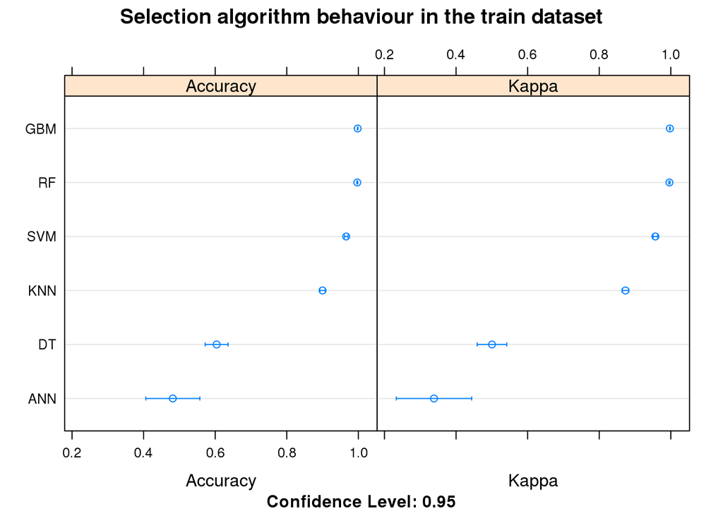

```r
dotplot(results, main= "Selection algorithm behaviour in the train dataset")
```

```r
acc_results_test <- c(cfKNN$overall['Accuracy'],
                      cfANN$overall['Accuracy'], cfSVM$overall['Accuracy'],
                      cfDT$overall['Accuracy'], cfRF$overall['Accuracy'], cfGBM$overall['Accuracy'])
kappa_results_test <- c(cfKNN$overall['Kappa'],
                        cfANN$overall['Kappa'], cfSVM$overall['Kappa'],
                        cfDT$overall['Kappa'], cfRF$overall['Kappa'], cfGBM$overall['Kappa'])
spec_results_test <- c(cfKNN$byClass[3,1],
                       cfANN$byClass[3,1], cfSVM$byClass[3,1],
                       cfDT$byClass[3,1], cfRF$byClass[3,1], cfGBM$byClass[3,1])
res_table <- data.frame(Accuracy = acc_results_test, Kappa = kappa_results_test, Specificity_Classe = spec_results_test, row.names = c("k-Nearest Neighbour", "Artificial Neural Network", "Support Vector Machine", "Decision Tree", "Random Forest", "GBM"))
pander(res_table, keep.line.breaks = TRUE, style = 'grid', justify = 'left')
```

|  | Accuracy | Kappa | Specificity_Classe |
| --- | --- | --- | --- |
| **k-Nearest Neighbour** | 0.9147 | 0.8921 | 0.922 |
| **Artificial Neural Network** | 0.5244 | 0.4085 | 0.7183 |
| **Support Vector Machine** | 0.967 | 0.9582 | 0.9776 |
| **Decision Tree** | 0.6003 | 0.4956 | 0.8694 |
| **Random Forest** | 0.9959 | 0.9948 | 0.9961 |
| **GBM** | 0.9988 | 0.9985 | 1 |

As can be shown in the previous graphs, Boosting Machine learning gives the best prediction compared with the rest of the machine learning algorithms. Using this approach in roder to predict the `test` dataset gives the following results:

```r
predict(GBM_model, testing03[, -length(names(testing03))])
```

```
##  [1] B A B A A E D B A A B C B A E E A B B B
## Levels: A B C D E
```